# MAPOR 2017 Coding Hour: Graphics

### Trent Buskirk and Stas Kolenikov

### 2017-10-24

## MAPOR 2017 R coding hour (Buskirk + Kolenikov)

## Script 2: graphics

### Index plot

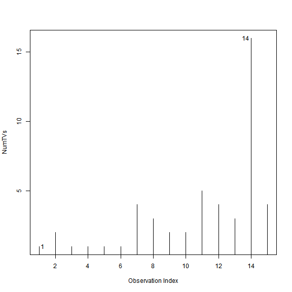

```
14  1
14  1
```

```r
> setwd("C:/Users/kolenikovs/Conferences/MAPOR.2017/R with Trent")
> load("datasets/WorkshopData.RData")
> Rtest <- rtest
> with(Rtest, indexplot(NumTVs, type='h', id.method='y', id.n=2,
+   labels=rownames(Rtest)))
```

### Histogram

This is a default run:

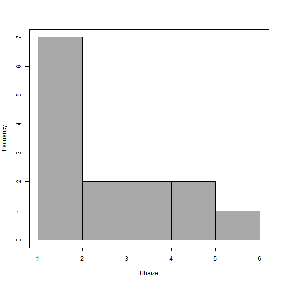

```r
> with(Rtest, Hist(Hhsize, scale="frequency", breaks="Sturges",
+   col="darkgray"))
```

First, in R Commander GUI, we selected the `percent` option as the y-axis:

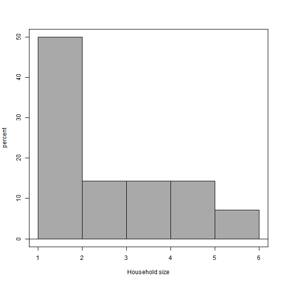

```r
> with(Rtest, Hist(Hhsize, scale="percent", breaks="Sturges", col="darkgray",
+   xlab="Household size"))
```

Then we changed the color to green (`#00CD00`)…

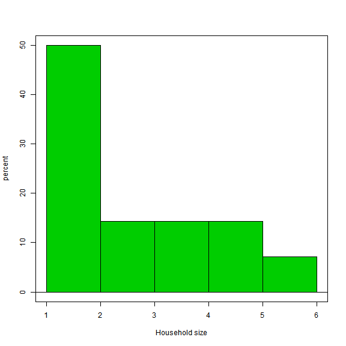

```r
> with(Rtest, Hist(Hhsize, scale="percent", breaks="Sturges", col=3,
+   xlab="Household size"))
```

… and to blue (`#0000FF`)

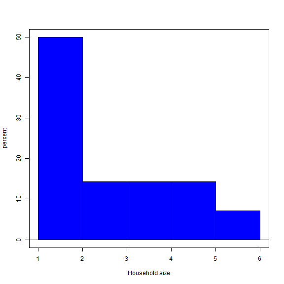

```r
> with(Rtest, Hist(Hhsize, scale="percent", breaks="Sturges", col=4,
+   xlab="Household size"))
```

Export the graph file to disk:

```r
> dev.print(png,
+ +   filename="HHsize-hist.png",
+ +    width=1000, height=998, pointsize=12, units="px")
```

```
Error: <text>:2:13: unexpected '='
1: dev.print(png,
2: +   filename=
               ^
```

### Kernel density plot

Kernel density estimate is a version of density representation that produces a smooth line rather than bars, like historgrams do.

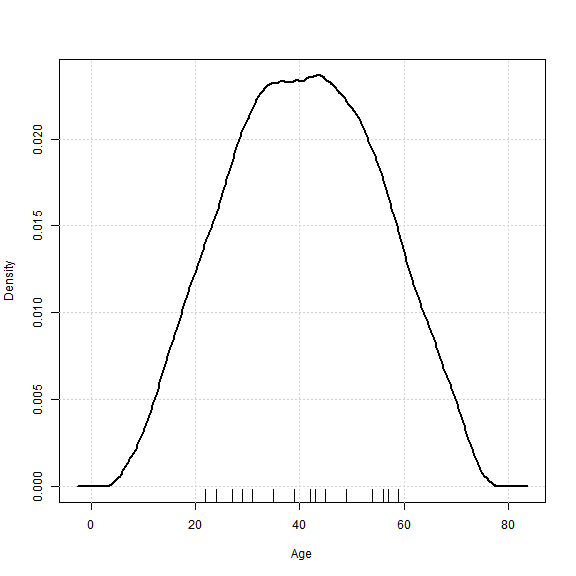

```r
> densityPlot( ~ AgeofPanelist, data=Rtest, bw="SJ", adjust=1,
+   kernel="epanechnikov", xlab="Age")
```

### Scatterplots

Scatterplots demonstrate the relations between two continuous variables. The relations may be monotone (i.e., one variable goes up as the other goes up or down), curvlinear with change of trends, cluster (i.e., groups of observations separated in space), etc.

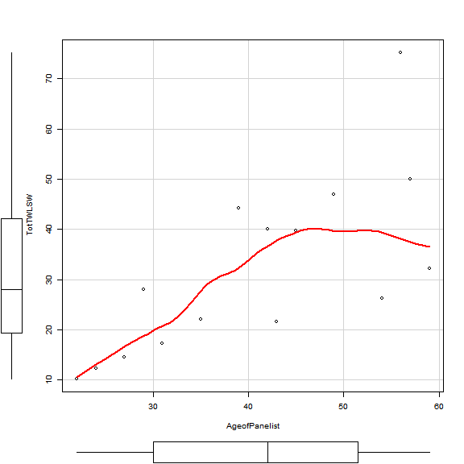

```r
> scatterplot(TotTWLSW~AgeofPanelist, reg.line=FALSE, smooth=TRUE,
+   spread=FALSE, boxplots='xy', span=0.5, ellipse=FALSE, levels=c(.5, .9),
+   data=Rtest)
```

### Violin plot

```r
> library(vioplot)
```

```
Package 'sm', version 2.2-5.4: type help(sm) for summary information
```

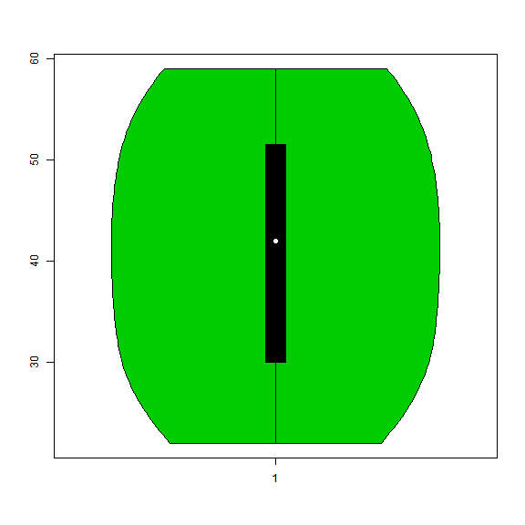

```r
> vioplot(Rtest$AgeofPanelist,col="green3")
```

## Example 2.1

> Using the dataBodyMeas dataset in the lessR package:

> (a) plot a histogram of heights and use percentages as the basis of histogram (as opposed to frequencies)

> (b) plot a density estimate of the heights (adjust =1.2)

> © generate a boxplot of the heights.

> (d) generate a violin plot of the heights – try two different values of the `h` parameter – try .3 and 1 and 4 and three different colors = “green”, “red” and “magenta”

```r
> library(lessR)
```

[output not shown]

```r
> data(dataBodyMeas)
```

### Example 2.1.a

> plot a histogram of heights and use percentages as the basis of histogram (as opposed to frequencies)

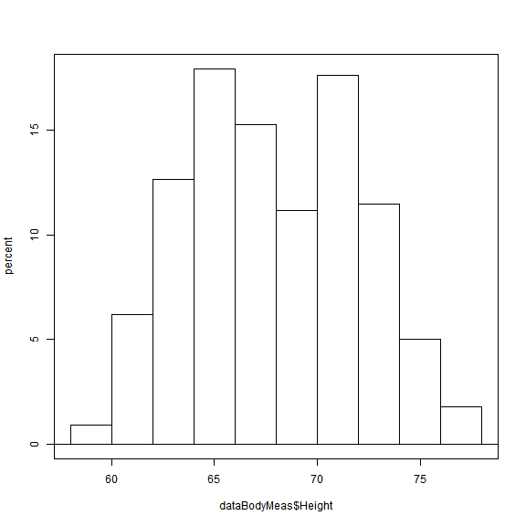

```r
> Hist(dataBodyMeas$Height,scale="percent")
```

### Example 2.1.b

> plot a density estimate of the heights (adjust =1.2)

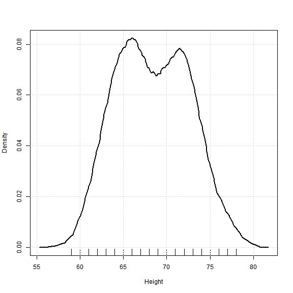

```r
> densityPlot( ~ Height, data=dataBodyMeas, bw="SJ", adjust=1.2,
+   kernel="epanechnikov")
```

### Example 2.1.c

> generate a boxplot of the heights.

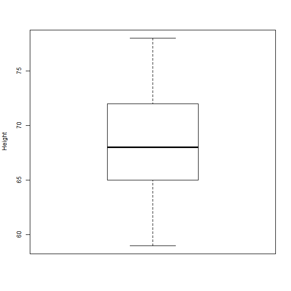

```r
> Boxplot( ~ Height, data=dataBodyMeas, id.method="y")
```

### Example 2.1.d

> generate a violin plot of the heights – try two different values of the `h` parameter – try .3 and 1 and 4 and three different colors = “green”, “red” and “magenta”

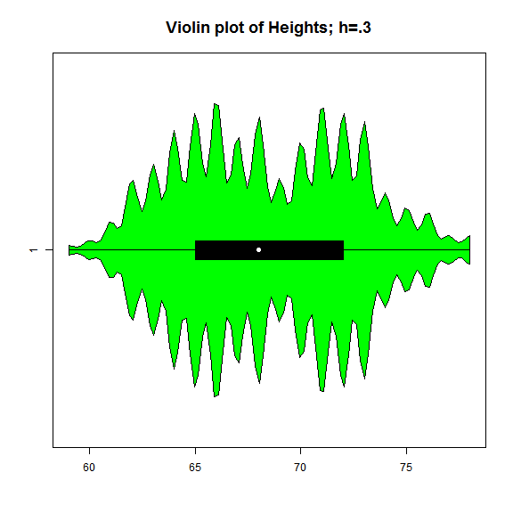

```r
> vioplot(dataBodyMeas$Height, col=c("green"), h=.3, horizontal=TRUE)
> title("Violin plot of Heights; h=.3", cex.main=1.5)
```

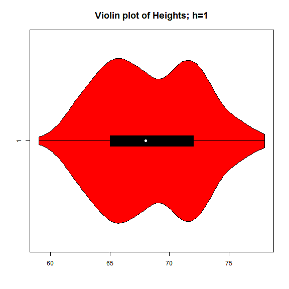

```r
> vioplot(dataBodyMeas$Height, col=c("red"), h=1, horizontal=TRUE)
> title("Violin plot of Heights; h=1", cex.main=1.5)
```

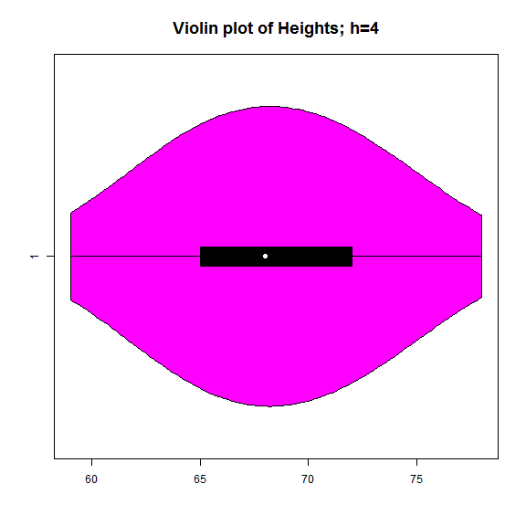

```r
> vioplot(dataBodyMeas$Height, col=c("magenta"), h=4, horizontal=TRUE)
> title("Violin plot of Heights; h=4", cex.main=1.5)
```

## Example 2.2

### Example 2.2.a

> Using dataBodyMeas dataset in the lessR package, plot a density estimate of the heights distribution for males and females using the Epanechnikov kernel function with default values. (multiplier of 1)

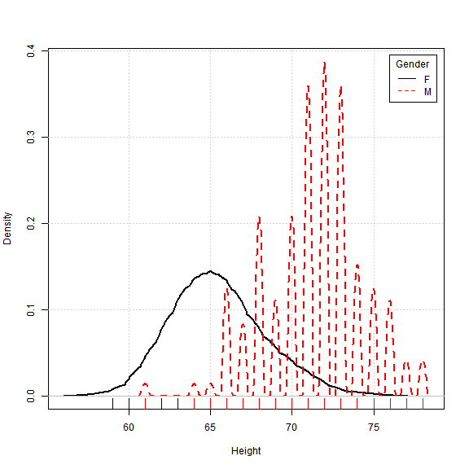

```r
> densityPlot(Height~Gender, data=dataBodyMeas, bw="SJ", adjust=1,
+    kernel="epanechnikov")
```

### Example 2.2.b

> Repeat (a) but apply a multiplier of 1 for females and 5 for males to the default bandwidth. [Males have larger variability so we increase the multiplier to “smooth out the plot”]. Use the 2nd and 4th colors in your palette.

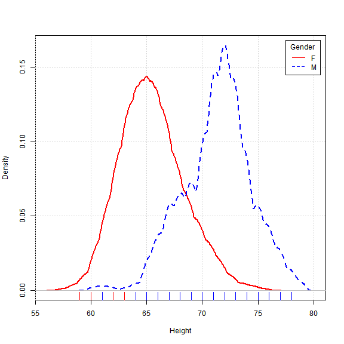

```r
> densityPlot(Height~Gender, data=dataBodyMeas, bw="SJ", adjust=c(1,5),
+   kernel="epanechnikov",col=c(2,4))
```

### Example 2.2.c

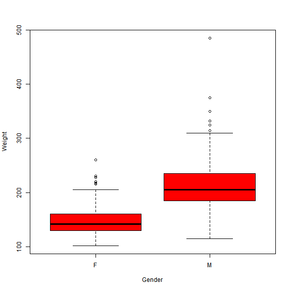

```r
> Boxplot(Weight~Gender,data=dataBodyMeas,col=2,id.method="none")
```

## Scatterplots and scatterplot matrices

Rcommander can generate scatterplots that have extended features including:

- loess smothed curves (locally weighted scatterplot smoothing)
- spread of the smooth curve (variance+bias)
- least squares regression line
- marginal boxplots

Rcommander can also generate scatterplot matrices

- histograms, density plots or boxplots along the diagonal

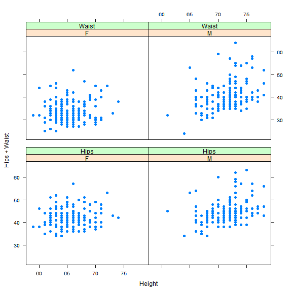

```r
> library(lattice, pos=16)
> xyplot(Hips + Waist ~ Height | Gender, outer=TRUE, layout=c( 2 * 1 , 2 ) ,
+   between=list(x=c( 0 ), y=1), type="p", pch=16, auto.key=list(border=TRUE),
+   par.settings=simpleTheme(pch=16), scales=list(x=list(relation='same'),
+   y=list(relation='same')), data=dataBodyMeas)
```

## Example 2.3

Using `data(dataBodyMeas)`, produce a bunch of scatterplots

### Example 2.3.a

> Using the dataBodyMeas dataset in the lessR package, create a scatterplot depicting the relationship between waist (X) and hip circumference (Y).
> - Label the x-axis “Waist Circumference” and the y-axis “Hip Measure”.  
>   Also plot marginal boxplots on the scatterplot axes.  
>   All labels should have a multiplier of 1.2. Point size should also have a multiplier of 1.3 and NO points should be labelled.

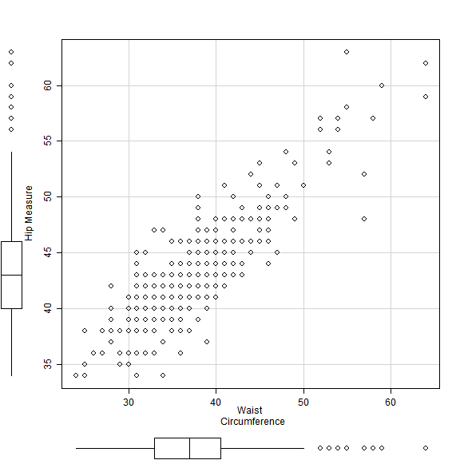

```r
> scatterplot(Hips~Waist, reg.line=FALSE, smooth=FALSE, spread=FALSE,
+   boxplots='xy', span=0.5, ellipse=FALSE, levels=c(.5, .9), xlab="Waist
+   Circumference", ylab="Hip Measure", cex=1.3, cex.axis=1.2, cex.lab=1.2,
+   data=dataBodyMeas)
```

As cases with identical hip/waist measurements are glued together on the plot, it may make sense to jitter both measures, so that the said overlap is broken.

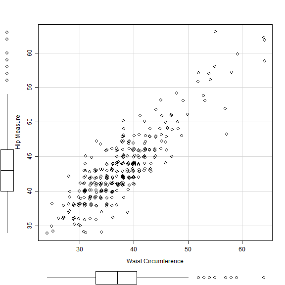

```r
> scatterplot(Hips~Waist, reg.line=FALSE, smooth=FALSE, spread=FALSE,
+   boxplots='xy', span=0.5, ellipse=FALSE, levels=c(.5, .9), jitter=list(x=1,
+   y=1), xlab="Waist Circumference", ylab="Hip Measure", cex=1.3, cex.axis=1.2,
+    cex.lab=1.2, data=dataBodyMeas)
```

### Example 2.3.b

> Using this same dataset, create a scatterplot matrix of height, weight and waist size.
> - choose histograms for the diagonal and do not plot additional lines or identify any points within each plot.

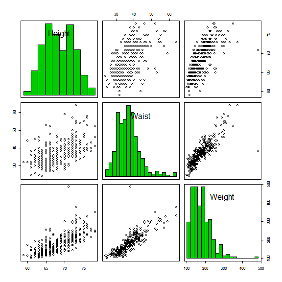

```r
> scatterplotMatrix(~Height+Waist+Weight, reg.line=FALSE, smooth=FALSE,
+   spread=FALSE, span=0.5, ellipse=FALSE, levels=c(.5, .9), id.n=0, diagonal =
+   'histogram', data=dataBodyMeas)
```

### Example 2.3.c

> Create a `ShoeBin` variable that has 4 groups of equal size, then use this variable to construct a plot of mean heights for each of the four `Shoebin` groups. Include standard deviations in the plot.
> - Label the y-axis “Mean Heights (and Std. Dev)” and the x-axis “Shoe Size Quartile Groups”

Creating four bins of `Shoe`:

```r
> dataBodyMeas$ShoeBin4 <- with(dataBodyMeas, bin.var(Shoe, bins=4,
+   method='proportions', labels=NULL))
> table(dataBodyMeas$ShoeBin4)
```

```
  [4.5,8]     (8,9]  (9,10.6] (10.6,16]
      118        68        69        85
```

Plotting height by quartiles of `ShoeBin4`:

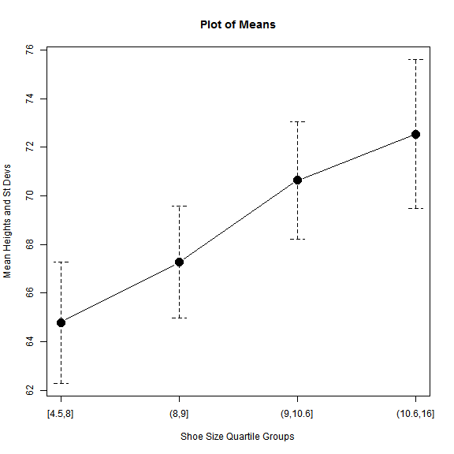

```r
> with(dataBodyMeas, plotMeans(Height, ShoeBin4, error.bars="sd",
+   xlab="Shoe Size Quartile Groups", ylab="Mean Heights and St Devs",
+   connect=TRUE))
```

### Example 2.3.d

> Create a plot of `height` (X) versus `weight` (Y) by conditioning on `shoe` size quartile and `gender`.
> - Allow the x-axis to remain the same for all plots, but allow the y-axis to vary freely. Use the plotting symbol of a solid square (`pch=15`) and make its color the fourth one in your palette.

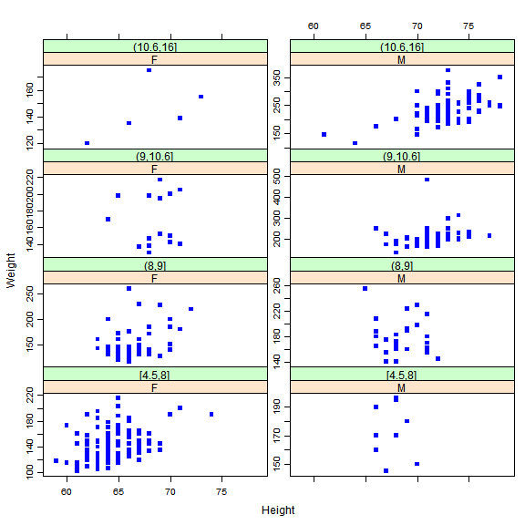

```r
> xyplot(Weight ~ Height | Gender + ShoeBin4, type="p", pch=15,
+   auto.key=list(border=TRUE), par.settings=simpleTheme(pch=15),
+   scales=list(x=list(relation='same'), y=list(relation='free')),
+   data=dataBodyMeas, col=4)
```

## Plots for categorical variables

`Rcommander` can easily produce **basic** graphs specifically relevant for categorical variables including:

- Pie Graphs
- Bar Charts (best with one categorical variable) `lessR` graphics capabilities for categorical variables extends the capabilities of Rcommander
- Bubble plots
- expanded bar charts (multiple categorical variables)
- Sunflower plots

### Bar charts

From RCommander GUI:

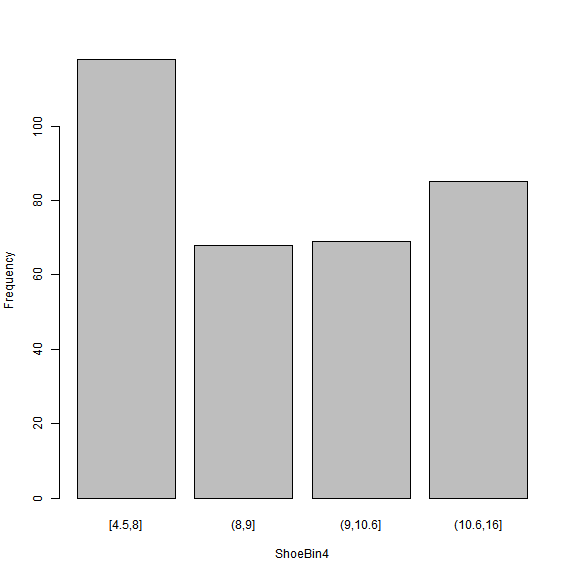

```r
> with(dataBodyMeas, Barplot(ShoeBin4, xlab="ShoeBin4", ylab="Frequency"))
```

Using `lessR`:

```
--- Gender ---

                   F      M     Total
Frequencies:     170    170       340
Proportions:   0.500  0.500     1.000


Chi-squared test of null hypothesis of equal probabilities
  Chisq = 0.000, df = 1, p-value = 1.000
```

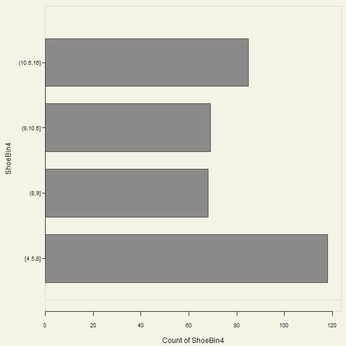

```
--- ShoeBin4 ---

               [4.5,8]  (8,9]  (9,10.6]  (10.6,16]     Total
Frequencies:       118     68        69         85       340
Proportions:     0.347  0.200     0.203      0.250     1.000


Chi-squared test of null hypothesis of equal probabilities
  Chisq = 19.224, df = 3, p-value = 0.000
```

```r
>  BarChart(ShoeBin4, data=dataBodyMeas, horiz=TRUE)
```

Note the interesting suggestions `lessR` made:

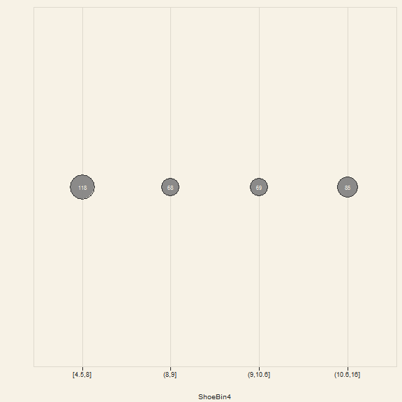

```
>>> Suggestions
Plot(ShoeBin4, data=dataBodyMeas, color.low="lemonchiffon2", color.hi="maroon3")
Plot(ShoeBin4, values="count")  # scatter plot of counts


--- ShoeBin4 ---

               [4.5,8]  (8,9]  (9,10.6]  (10.6,16]     Total
Frequencies:       118     68        69         85       340
Proportions:     0.347  0.200     0.203      0.250     1.000


Chi-squared test of null hypothesis of equal probabilities
  Chisq = 19.224, df = 3, p-value = 0.000
```

```r
> Plot(ShoeBin4, data=dataBodyMeas)  # bubble plot
```

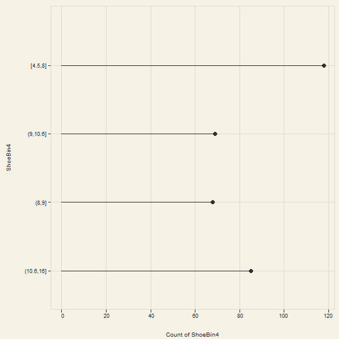

```r
> Plot(ShoeBin4, values="count", data=dataBodyMeas)  # scatter plot
```

```
--- Gender ---

                   F      M     Total
Frequencies:     170    170       340
Proportions:   0.500  0.500     1.000


Chi-squared test of null hypothesis of equal probabilities
  Chisq = 0.000, df = 1, p-value = 1.000
```

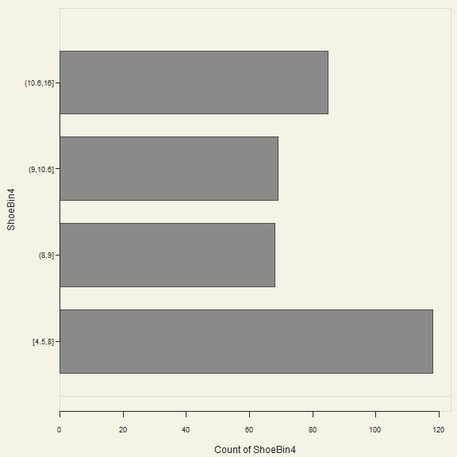

```
--- ShoeBin4 ---

               [4.5,8]  (8,9]  (9,10.6]  (10.6,16]     Total
Frequencies:       118     68        69         85       340
Proportions:     0.347  0.200     0.203      0.250     1.000


Chi-squared test of null hypothesis of equal probabilities
  Chisq = 19.224, df = 3, p-value = 0.000
```

```r
> BarChart(ShoeBin4, horiz=TRUE, data=dataBodyMeas)  # horizontal bar chart
```

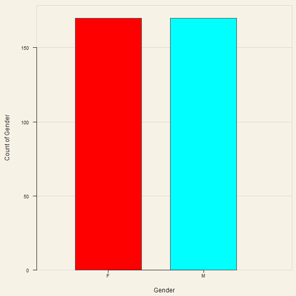

```
--- Gender ---

                   F      M     Total
Frequencies:     170    170       340
Proportions:   0.500  0.500     1.000


Chi-squared test of null hypothesis of equal probabilities
  Chisq = 0.000, df = 1, p-value = 1.000
```

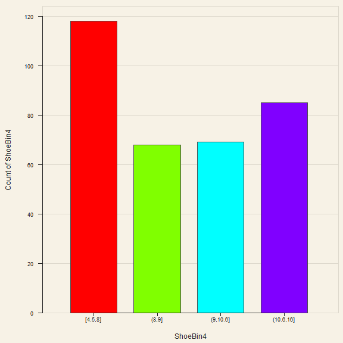

```
--- ShoeBin4 ---

               [4.5,8]  (8,9]  (9,10.6]  (10.6,16]     Total
Frequencies:       118     68        69         85       340
Proportions:     0.347  0.200     0.203      0.250     1.000


Chi-squared test of null hypothesis of equal probabilities
  Chisq = 19.224, df = 3, p-value = 0.000
```

```r
> BarChart(ShoeBin4, colors="rainbow", data=dataBodyMeas)  # different bar colors
```

Note, however, that `lessR` sometimes fails to pick up the right variable, and plots `Gender` instead of `ShoeBin4`.

Some suggested variations:

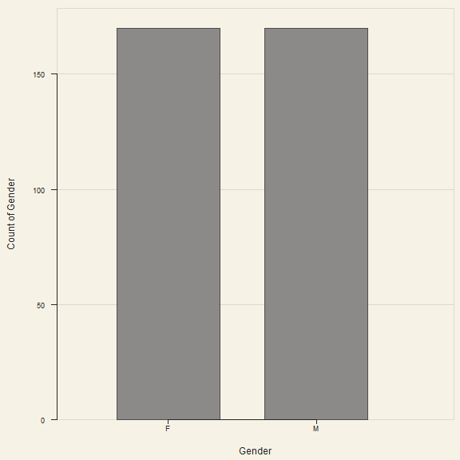

```
>>> Suggestions
Plot(Gender)  # bubble plot
Plot(Gender, values="count")  # scatter plot
BarChart(Gender, horiz=TRUE)  # horizontal bar chart
BarChart(Gender, colors="rainbow")  # different bar colors


--- Gender ---

                   F      M     Total
Frequencies:     170    170       340
Proportions:   0.500  0.500     1.000


Chi-squared test of null hypothesis of equal probabilities
  Chisq = 0.000, df = 1, p-value = 1.000
```

```r
> dataBodyMeas$ShoeBin4 <- with(dataBodyMeas, bin.var(Shoe, bins=4,
+   method='proportions', labels=NULL))
> # this has to be forced, as R reloads dataBodyMeas, apparently
> BarChart(Gender, by=ShoeBin4, data=dataBodyMeas)
```

```r
> BarChart(Gender, by=ShoeBin4, data=dataBodyMeas, horiz=TRUE)
```

```
>>> Suggestions
Plot(Gender)  # bubble plot
Plot(Gender, values="count")  # scatter plot
BarChart(Gender, horiz=TRUE)  # horizontal bar chart
BarChart(Gender, colors="rainbow")  # different bar colors


--- Gender ---

                   F      M     Total
Frequencies:     170    170       340
Proportions:   0.500  0.500     1.000


Chi-squared test of null hypothesis of equal probabilities
  Chisq = 0.000, df = 1, p-value = 1.000
```

```r
> BarChart(Gender, by=ShoeBin4, data=dataBodyMeas, beside=TRUE)
```

```
Error:
------
beside=TRUE  is not valid for analysis of only one variable.
```

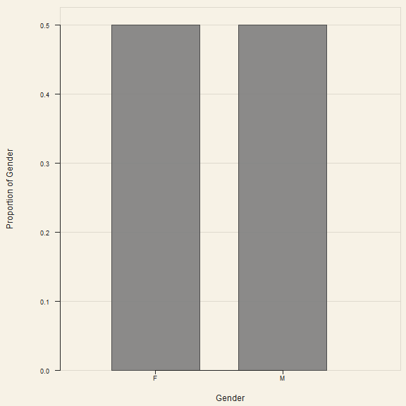

```
>>> Suggestions
Plot(Gender)  # bubble plot
Plot(Gender, values="count")  # scatter plot
BarChart(Gender, horiz=TRUE)  # horizontal bar chart
BarChart(Gender, colors="rainbow")  # different bar colors


--- Gender ---

                   F      M     Total
Frequencies:     170    170       340
Proportions:   0.500  0.500     1.000


Chi-squared test of null hypothesis of equal probabilities
  Chisq = 0.000, df = 1, p-value = 1.000
```

```r
> BarChart(Gender, by=ShoeBin4, data=dataBodyMeas, prop=TRUE)
```

### Bubble plots

Bubble plots enhance two or three-dimensional scatterplots by allowing the inclusion of an additional variable that governs the size of plotted points. Bubble plots can be drawn easily using the `ScatterPlot()` function in the `lessR` package.

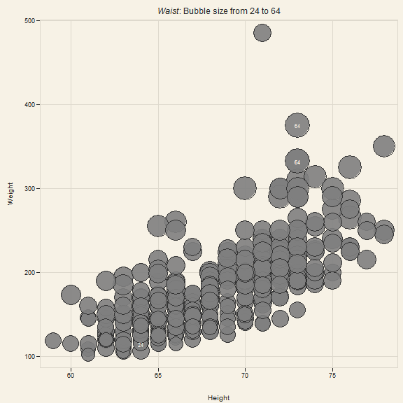

```
>>> Suggestions
Plot(Height, Weight, fit="ls", fit.se=1:3)  # fit line with standard errors
Plot(Height, Weight, out.cut=.10)  # label top 10% potential outliers
Plot(Height, Weight, ellipse=0.95, add="means")  # 0.95 ellipse with means
Plot(Height, Weight, shape="diamond")  # change plot character


>>> Pearson's product-moment correlation

Number of paired values with neither missing, n = 340


Sample Correlation of Height and Weight: r = 0.702


Alternative Hypothesis: True correlation is not equal to 0
  t-value: 18.136,  df: 338,  p-value: 0.000

95% Confidence Interval of Population Correlation
  Lower Bound: 0.644      Upper Bound: 0.752
```

```r
> ScatterPlot(Height, Weight, data=dataBodyMeas, size=Waist,
+ bubble.power=.25, shape="circle")
```

Note that some of the `bubble` options have apparently changed between versions.

Bubble plots can be conveniently used to visualize categorical variables, as well. Bubble plots applied to two categorical variables (stored as numeric variables in R with fewer than 10 unique values each) is a way to create a more informative scatterplot where the size of the plotted point is proportional to another value. Commonly this value is the frequency of the cell formed by the cross tabulation of the two categorical variables.

```r
> mydata <- dataBodyMeas
> mydata$ShoeBin4 <- with(mydata, bin.var(Shoe, bins=4,
+   method='proportions', labels=NULL))
> dataBodyMeasSum <- as.data.frame(table(mydata$ShoeBin4,mydata$Gender))
> colnames(dataBodyMeasSum) <- c("ShoeBin4","Gender","Freq")
> ScatterPlot(Gender,ShoeBin4,data=dataBodyMeasSum,size=Freq)
```

[output not shown]

Another variation on the topic of using a count variable to be added to the location on the scatterplot is the sunflower plot. In this plot, each point is depicted as a “sunflower” with the number of petals being proportional to another variable – most commonly, the joint frequency of the specific levels of the two categorical variables, considered together in a cross-tabulated contingency table.

```r
> # canonical version -- not sure if it works
> ScatterPlot(Gender,ShoeBin4,data=mydata,size=Freq,shape="sunflower")
```

[output not shown]

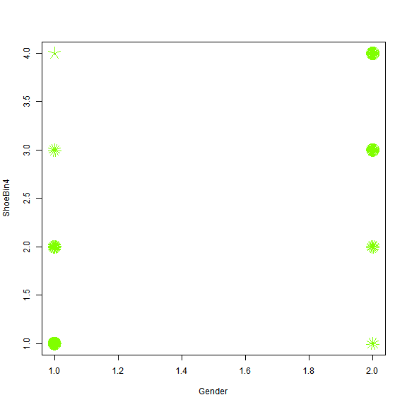

```r
> # alternative -- the ticks and axes work poorly though
> sunflowerplot(ShoeBin4~Gender,data=dataBodyMeas)
```

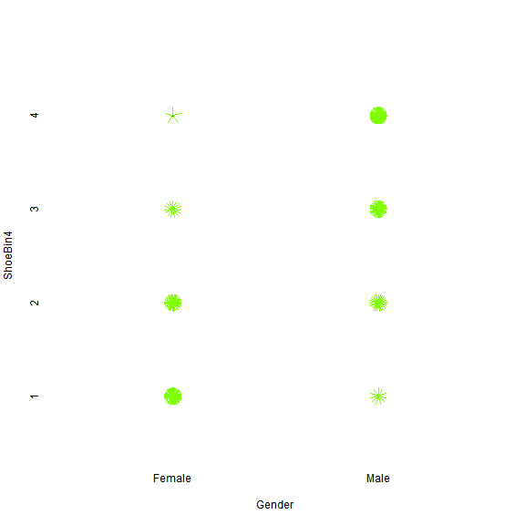

```r
> sunflowerplot(ShoeBin4~Gender,data=dataBodyMeas,xlim=c(0.5,2.5),ylim=c(0.5,4.5),axes=FALSE)
> axis(side=1,at=c(1,2),labels=c("Female","Male"),lwd=0)
> axis(side=2,at=1:4,lwd=0)
```

## Example 2.4

The dataset `dataMach4` from the `lessR` package contains `Gender` and 20 Likert scale items assessing the degree of Machiavellianism present in respondents. The Likert scales are 0=Strongly Disagree; 5=Strongly Agree.

```r
> data(dataMach4)
> dataMach4 <- within(dataMach4, {
+   GenderNum <- as.factor(Gender)
+ })
> LikertCats <- c("Strongly Disagree", "Disagree", "Slightly Disagree","Slightly Agree", "Agree", "Strongly Agree")
```

### Example 2.4.b

> Create a horizontal bar chart for item `m06`:
> - Honesty is the Best Policy displaying proportions instead of frequencies

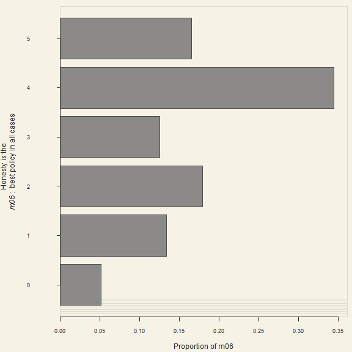

```
>>> Suggestions
Plot(m06)  # bubble plot
Plot(m06, values="count")  # scatter plot
BarChart(m06, horiz=TRUE)  # horizontal bar chart
BarChart(m06, colors="rainbow")  # different bar colors


--- m06: Honesty is the best policy in all cases ---

                   0      1      2      3      4      5     Total
Frequencies:      18     47     63     44    121     58       351
Proportions:   0.051  0.134  0.179  0.125  0.345  0.165     1.000


Chi-squared test of null hypothesis of equal probabilities
  Chisq = 101.017, df = 5, p-value = 0.000
```

```r
> BarChart(m06,data=dataMach4,horiz=TRUE,prop=TRUE)
```

### Example 2.4.c

> Create a vertical bar chart for item `m07`: No Excuse for lying
> - separated by `Gender`

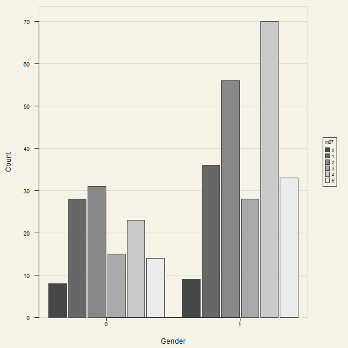

```
>>> Suggestions
Plot(Gender, m07)
SummaryStats(Gender, m07)  # or ss


Gender
  - by levels of -
m07: There is no excuse for lying to someone else

Joint and Marginal Frequencies
------------------------------

  Gender
m07     0   1 Sum
  0     8   9  17
  1    28  36  64
  2    31  56  87
  3    15  28  43
  4    23  70  93
  5    14  33  47
  Sum 119 232 351


Cramer's V: 0.152

Chi-square Test:  Chisq = 8.063, df = 5, p-value = 0.153
```

```r
> BarChart(Gender,data=dataMach4,by=m07,beside=TRUE)
```

The color scheme is different, and the variable label did not get through.

### Example 2.4.d

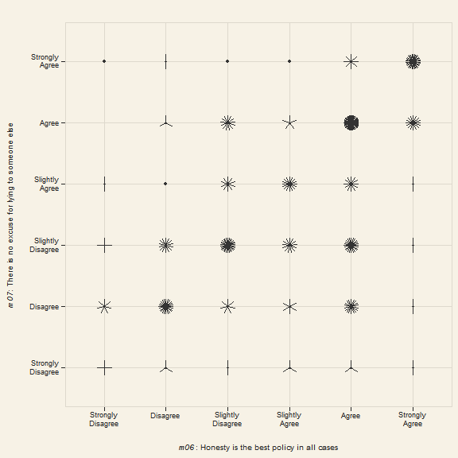

```
>>> Suggestions
ScatterPlot(m06, m07, data=dataMach4, value.labels=LikertCats, shape="sunflower", size.cut=FALSE)
ScatterPlot(m06, m07, data=dataMach4, value.labels=LikertCats, shape="sunflower", color.trans=.8, bg="off", grid="off")
SummaryStats(m06, m07)  # or ss


m06: Honesty is the best policy in all cases
  - by levels of -
m07: There is no excuse for lying to someone else

Joint and Marginal Frequencies
------------------------------

     m06
m07     0   1   2   3   4   5 Sum
  0     4   3   2   3   3   2  17
  1     7  24   7   6  18   2  64
  2     4  14  30  13  24   2  87
  3     2   1  10  16  12   2  43
  4     0   3  13   5  56  16  93
  5     1   2   1   1   8  34  47
  Sum  18  47  63  44 121  58 351


Cramer's V: 0.380

Chi-square Test:  Chisq = 253.103, df = 25, p-value = 0.000
>>> Low cell expected frequencies, chi-squared approximation may not be accurate
```

```r
> ScatterPlot(m06,  m07, data=dataMach4, value.labels=LikertCats, shape="sunflower")
```

# The End

That's all folks!